# R#3: stats with ggplot2

Laurent Modolo laurent.modolo@ens-lyon.fr

08 Nov 2019

# R#3: stats with ggplot2

The goal of this practical is to practices advanced features of `ggplot2`.

The objectives of this session will be to:

- learn about statistical transformations
- practices position adjustments
- change the coordinate systems

# `ggplot2` statistical transformations

We are going to use the `diamonds` data set included in `tidyverse`.

- Use the `help` and `View` command to explore this data set.
- Try the `str` command, which information are displayed ?

# `ggplot2` statistical transformations

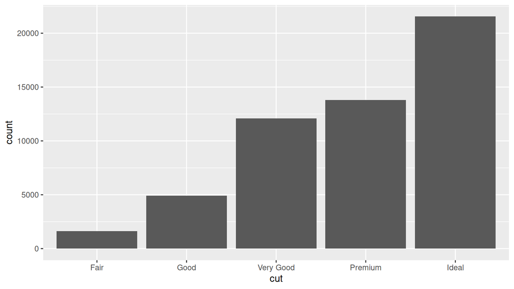

```r
ggplot(data = diamonds) +
  geom_bar(mapping = aes(x = cut))
```

More diamonds are available with high quality cuts.

# `ggplot2` statistical transformations

On the x-axis, the chart displays cut, a variable from diamonds. On the y-axis, it displays count, but count is not a variable in diamonds!

# `ggplot2` statistical transformations

You can generally use geoms and stats interchangeably. For example, you can recreate the previous plot using `stat_count()` instead of `geom_bar()`:

```r
ggplot(data = diamonds) +
  stat_count(mapping = aes(x = cut))
```

# `ggplot2` statistical transformations

# Statistical transformation challenge

```r
ggplot(data = diamonds) +
  geom_bar(mapping = aes(x = cut, y = ..prop..))
ggplot(data = diamonds) +
  geom_bar(mapping = aes(x = cut, fill = color, y = ..prop..))
```

# Position adjustments

You can colour a bar chart using either the `colour` aesthetic, or, more usefully, `fill`:

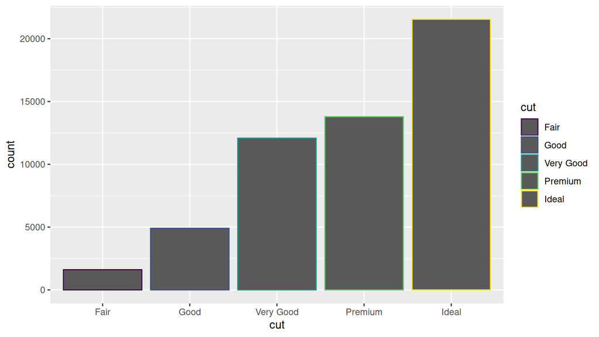

```r
ggplot(data = diamonds) +
  geom_bar(mapping = aes(x = cut, colour = cut))
```

# Position adjustments

You can colour a bar chart using either the `colour` aesthetic, or, more usefully, `fill`:

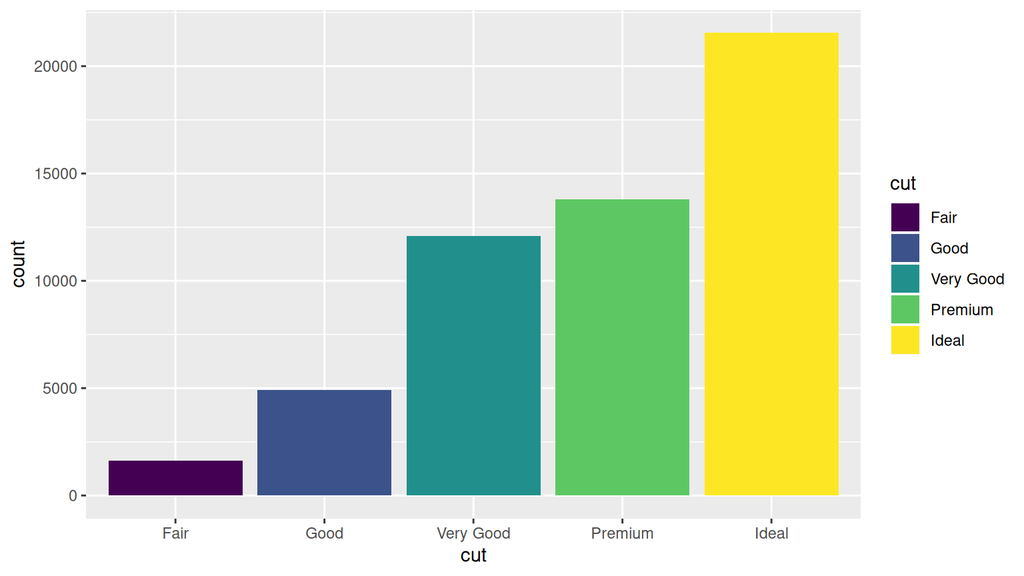

```r
ggplot(data = diamonds) +
  geom_bar(mapping = aes(x = cut, fill = cut))
```

# Position adjustments

You can also use `fill` with another variable:

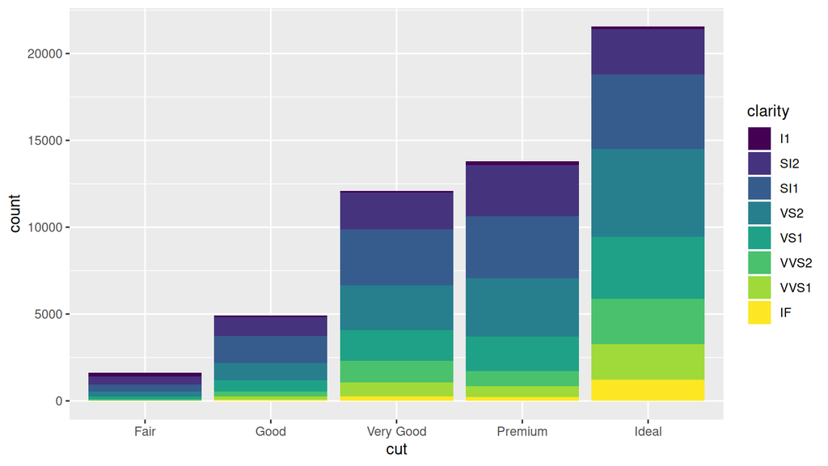

```r
ggplot(data = diamonds) +
  geom_bar(mapping = aes(x = cut, fill = clarity))
```

# Position adjustments

The stacking is performed by the position adjustment `position`

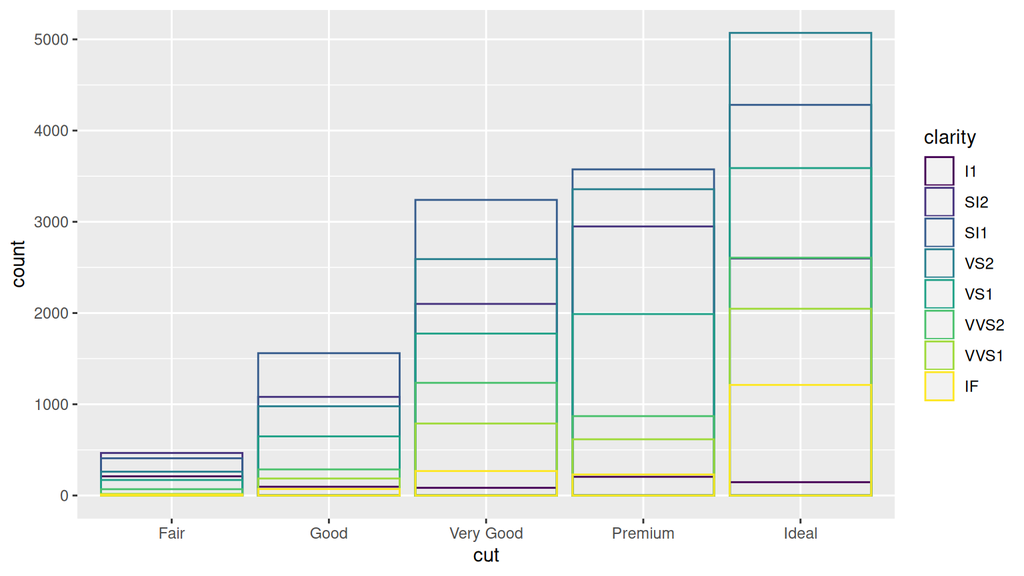

```r
ggplot(data = diamonds,
       mapping = aes(x = cut, colour = clarity)) +
  geom_bar(fill = NA, position = "identity")
```

# Position adjustments

The stacking is performed by the position adjustment `position`

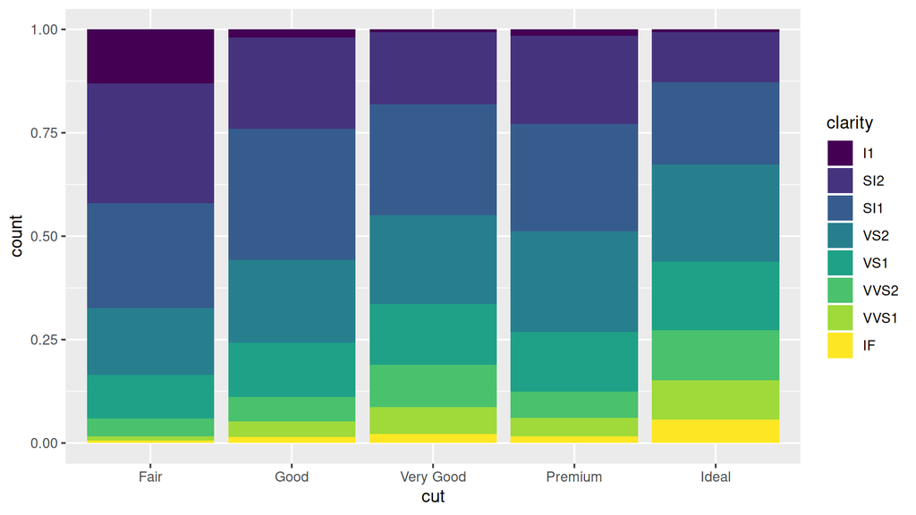

```r
ggplot(data = diamonds) +
  geom_bar(mapping = aes(x = cut, fill = clarity),
           position = "fill")
```

# Position adjustments

The stacking is performed by the position adjustment `position`

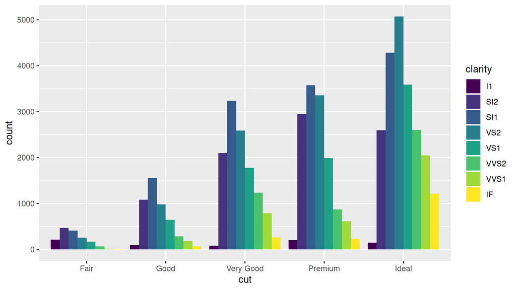

```r
ggplot(data = diamonds) +
  geom_bar(mapping = aes(x = cut, fill = clarity),
           position = "dodge")
```

# Position adjustments

The stacking is performed by the position adjustment `position`

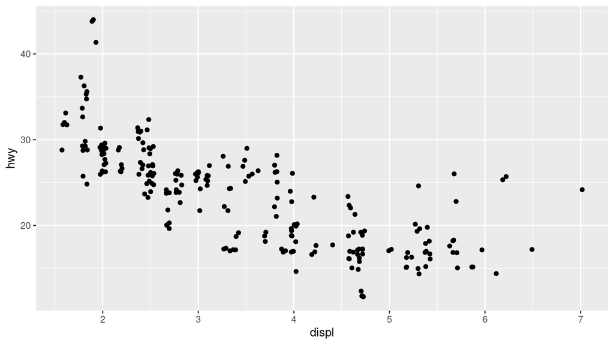

```r
ggplot(data = mpg) +
  geom_point(mapping = aes(x = displ, y = hwy),
             position = "jitter")
```

# Position adjustments

The stacking is performed by the position adjustment `position`

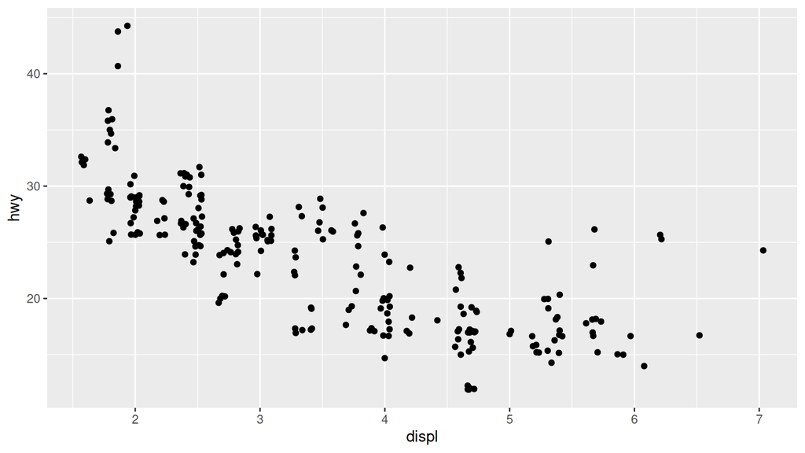

```r
ggplot(data = mpg) +
  geom_jitter(mapping = aes(x = displ, y = hwy))
```

# Position adjustments challenges

- What is the problem with this plot? How could you improve it?

```r
ggplot(data = mpg, mapping = aes(x = cty, y = hwy)) +
  geom_point()
```

- What parameters to `geom_jitter()` control the amount of jittering?
- Compare and contrast `geom_jitter()` with `geom_count()`
- What’s the default position adjustment for `geom_boxplot()` ? Create a visualisation of the `mpg` dataset that demonstrates it.

# Coordinate systems

Cartesian coordinate system where the x and y positions act independently to determine the location of each point. There are a number of other coordinate systems that are occasionally helpful.

# Coordinate systems

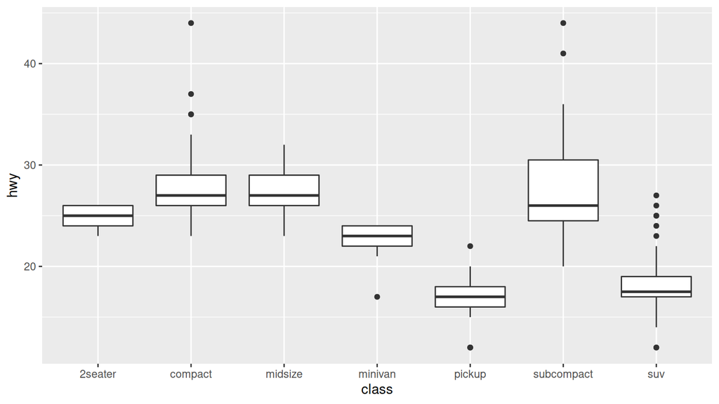

```r
ggplot(data = mpg, mapping = aes(x = class, y = hwy)) +
  geom_boxplot()
```

# Coordinate systems

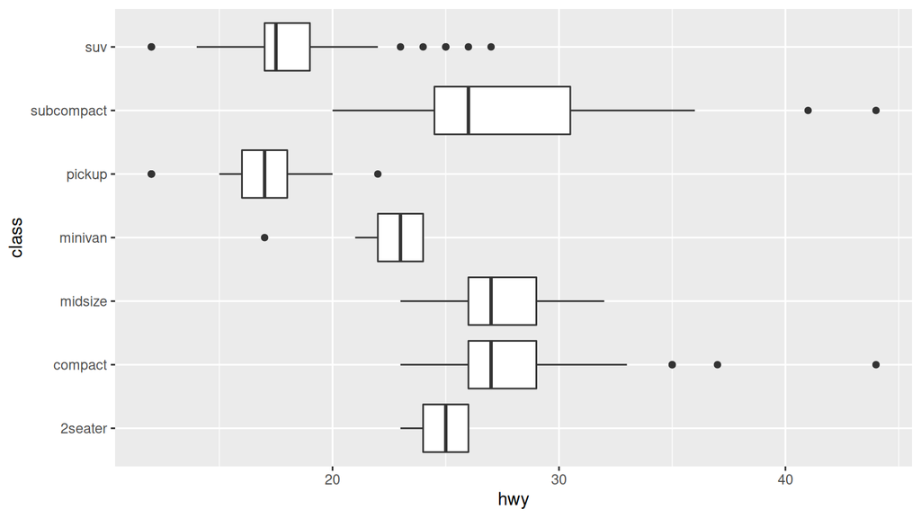

```r
ggplot(data = mpg, mapping = aes(x = class, y = hwy)) +
  geom_boxplot() +
  coord_flip()
```

# Coordinate systems

```r
bar <- ggplot(data = diamonds) +
  geom_bar(
    mapping = aes(x = cut, fill = cut),
    show.legend = FALSE,
    width = 1
  ) +
  theme(aspect.ratio = 1) +
  labs(x = NULL, y = NULL)
```

# Coordinate systems

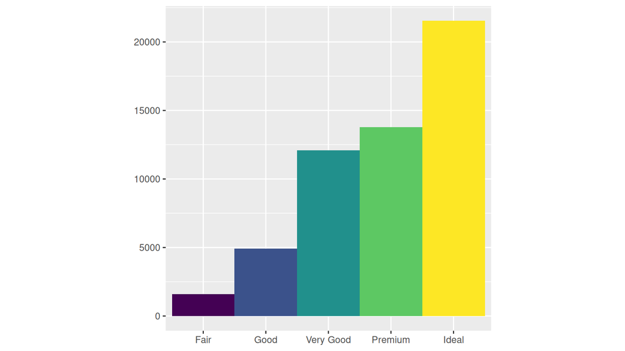

# Coordinate systems

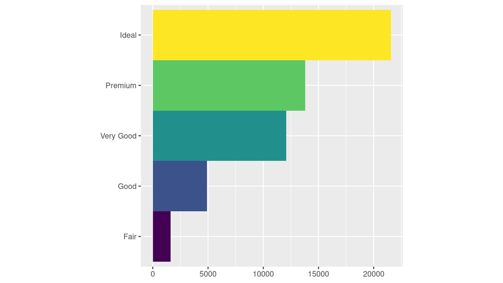

```r
bar + coord_flip()
```

# Coordinate systems

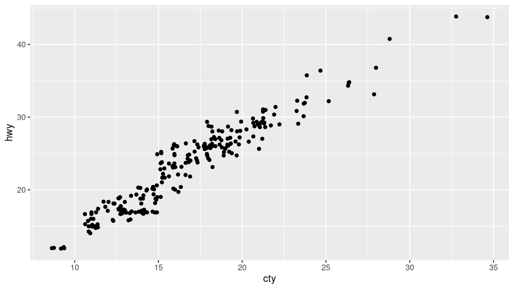

```r
ggplot(data = mpg) +
  geom_jitter(mapping = aes(x = cty, y = hwy))
```

# Coordinate systems

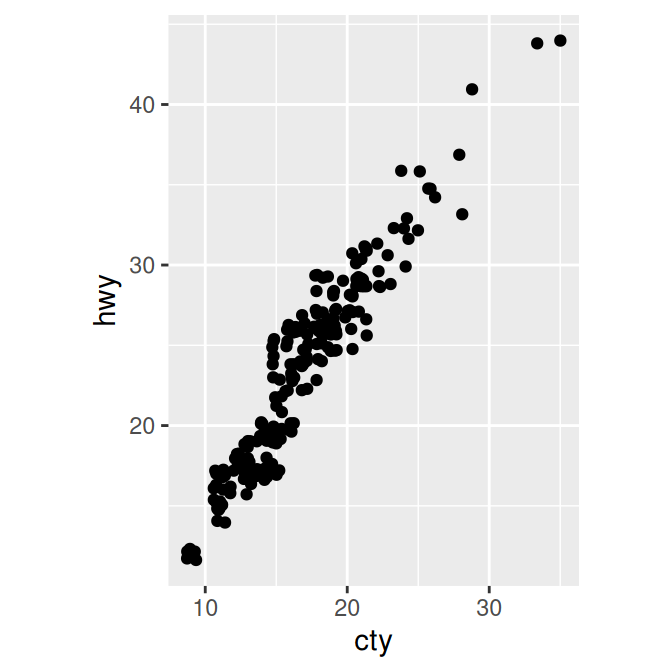

```r
ggplot(data = mpg) +
  geom_jitter(mapping = aes(x = cty, y = hwy)) +
  coord_quickmap()
```

# Coordinate systems

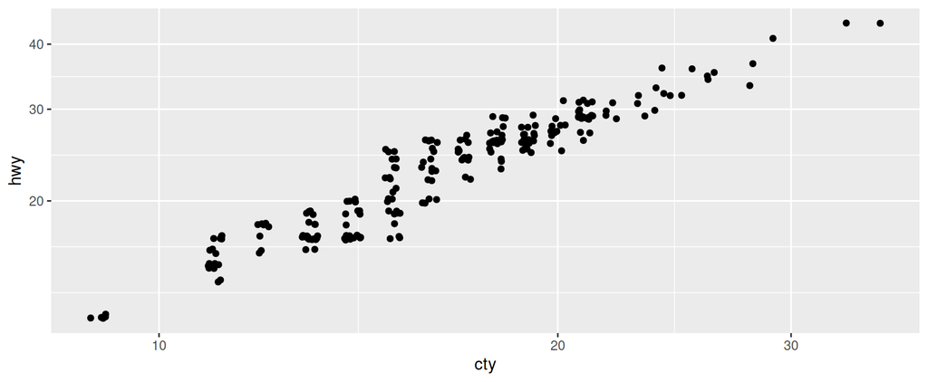

```r
ggplot(data = mpg) +
  geom_jitter(mapping = aes(x = cty, y = hwy)) +
  scale_y_log10() +
  scale_x_log10()
```

# Coordinate systems

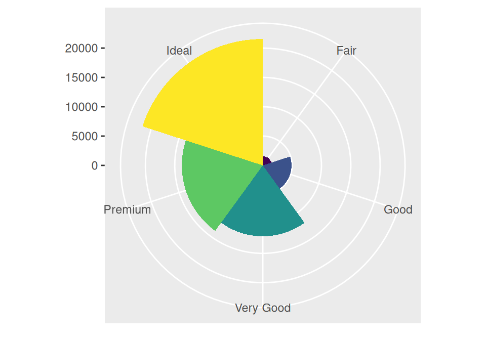

```r
bar + coord_polar()
```

# Coordinate systems challenges

- Turn a stacked bar chart into a pie chart using `coord_polar()`.
- What does `labs()` do? Read the documentation.
- What does the plot below tell you about the relationship between `city` and highway `mpg`? Why is `coord_fixed()` important? What does `geom_abline()` do?

```r
ggplot(data = mpg, mapping = aes(x = cty, y = hwy)) +
  geom_point() +
  geom_abline() +
  coord_fixed()
```

# Coordinate systems challenges

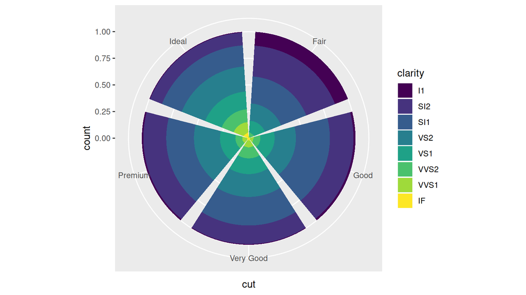

```r
ggplot(data = diamonds) +
  geom_bar(mapping = aes(x = cut, fill = clarity),
           position = "fill") +
  coord_polar()
```

# Coordinate systems challenges

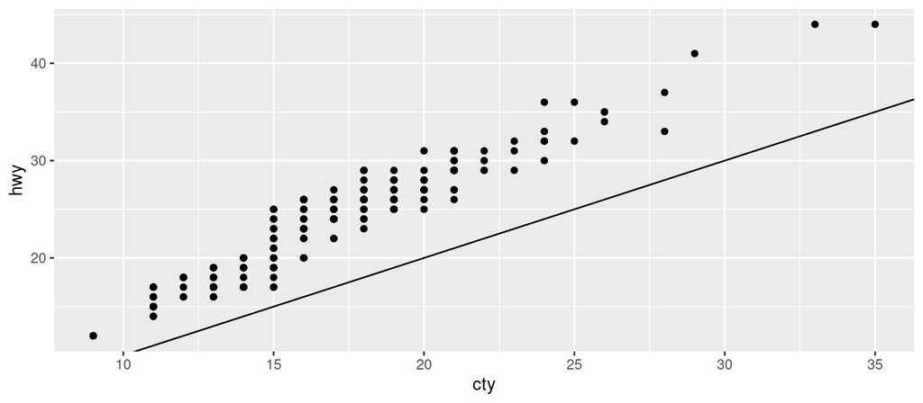

```r
ggplot(data = mpg, mapping = aes(x = cty, y = hwy)) +
  geom_point() +  geom_abline()
```

# Coordinate systems challenges

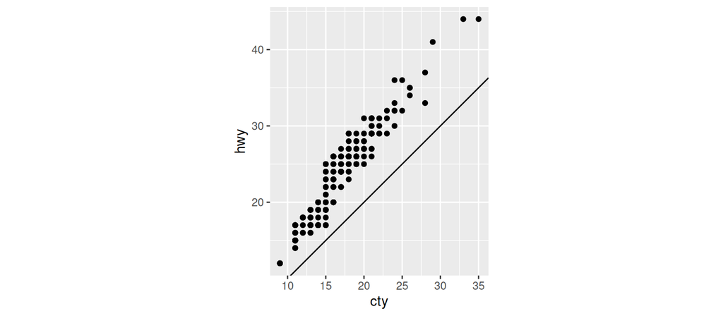

```r
ggplot(data = mpg, mapping = aes(x = cty, y = hwy)) +
  geom_point() +  geom_abline() + coord_fixed()
```